# Moving Average model

## **1. Conceptual Background**

### **1.1. MA(q) Model**

An **MA(q)** model forecasts the outcome variable $Y_T$ based solely on the past errors in the series - called **error lags**. Last month you made an estimation of sales amount. The degree to which you were wrong last month will be used to estimate the sales amount for next month. The sales amount itself is not used at all in our predictions. This is one of the main characteristics that sets MA(q) apart from **AR(q)** models. This story can be summarized in the following equation for an **MA(q)** model in its most basic form, the **MA(1)** model.

$$Y_t = \mu + \theta\varepsilon_{t-1} + \varepsilon_t$$

#### **1.1.2. The meaning of ‘error’**

But what does an error really mean? Well let’s pretend that you have two lines in a time series. One line is your predicted Sales. One is the actual sales made. Essentially, it is how wrong you were yesterday, that is affecting the prediction of tomorrow. The error reflects some sort of external shock due to some hidden factors (in the sense that they are not included in the model). Essentially, you can think of lagged errors as one long term effect minus some slightly less long term effect which gives us a short term effect.

#### **1.1.3. How can one predict the first observation if there was no error?**

If you have no prediction for the first observation, how can you start? Well, typically you would start out with the mean of the time series. *If your time series is long enough, it really won’t matter where your starting point is*.

### **1.2. The ‘Short Memory Model’**

One of the reasons why we shouldn’t care about where to begin is the fact that MA is a *short memory model*. This means that error’s don’t last long in the future.

- In AR(1) models, the effect of shocks that happen long ago have little effect on the present if $|\theta| < 1$.
- In MA(1) models, the effect of shocks have *NO* effect on the present if they happened long enough ago.

Let’s have a look at equations for yesterday, today, and tomorrow prediction of sales:

$$Y_t = \mu + \theta\varepsilon_{t-2} + \varepsilon_t$$
$$Y_t = \mu + \theta\varepsilon_{t-1} + \varepsilon_t$$
$$Y_{t+1} = \mu + \theta\varepsilon_1 + \varepsilon_{t+1}$$

As you can see, the error from yesterday has *no part* in predicting the error for today. It’s basically going back to this idea of stationarity. Stationarity was the idea that the dependence of previous observations declines over time. In MA processes, dependence of previous observations actually *disappears* as long as you go far enough into the future.

With Autoregressive models if we look back in time, the first observation still maters (even if this is a very tiny amount). For MA models, there will be literally *NO* effect if you go back in time far enough.

### **1.3. Some facts on MA processes**

An MA process…

- ACF has only one spike
- PACF decays exponentially
- MA(1) is equivalent to AR($\infty$) if $|\theta| < 1$
- No stationarity restriction required
- Mean is time-independent. Series return to their historical level
- variance is time-independent. Series return to their historical level

### **1.4. Reasons for MA behaviour in marketing**

There can be either a positive or negative MA behavior in marketing. **Postive behavior**: Higher beer sales today due to unexpected heat wave, but also likely tomorrow as heat wave stays on. **Negative relation**: Equilibrium-seeking behaviour of supply and demand such as natural disaster, coronavirus, et cetera.

### **1.5. When is an MA($q$) Process Present and at what order?**

Contrary to **AR($q$) Processes**, a purely **MA($q$)** process can be identified using the autocorrelation function. A purely **MA($q$)** process is a process in which *no future value can be predicted by its previous value*. Think of it like the baseline of a pure **MA($q$)** process is white noise with one ‘random’ shock that deviates substantially and significantly from this white noise series. This means that for the one lag in which such a shock occurs, due to the local variance there will actually be significant autocorrelation. Thus we can state that for an $MA(q)$, $\rho_k=0$ for all $k > q$.

Invertibility requires $0 < \varphi < 1$.

*More to come…*

## **2. Case example**

### **2.1. Plotting the Time Series Data**

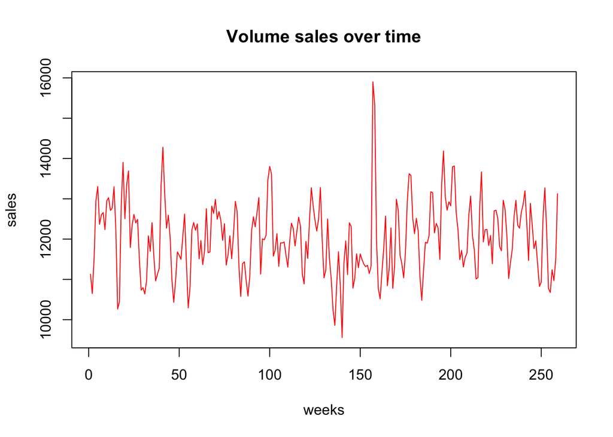

```r
plot(food.df[,c(1)],food.df[,c(3)], type="l", col="red", lwd=1, xlab="weeks", ylab="sales", main="Volume sales over time")
```

```r
adf.test(food.df[,c(3)])
```

```
## Augmented Dickey-Fuller Test
## alternative: stationary
##
## Type 1: no drift no trend
##      lag    ADF p.value
## [1,]   0 -0.431   0.520
## [2,]   1 -0.414   0.525
## [3,]   2 -0.253   0.571
## [4,]   3 -0.326   0.550
## [5,]   4 -0.307   0.556
## Type 2: with drift no trend
##      lag    ADF p.value
## [1,]   0  -8.66    0.01
## [2,]   1 -10.70    0.01
## [3,]   2  -7.42    0.01
## [4,]   3  -7.79    0.01
## [5,]   4  -6.06    0.01
## Type 3: with drift and trend
##      lag    ADF p.value
## [1,]   0  -8.64    0.01
## [2,]   1 -10.68    0.01
## [3,]   2  -7.41    0.01
## [4,]   3  -7.78    0.01
## [5,]   4  -6.06    0.01
## ----
## Note: in fact, p.value = 0.01 means p.value <= 0.01
```

#### **2.2.2. determining type and order with ACF & PACF**

We can recognize MA(1) by observing the ACF and PACF.

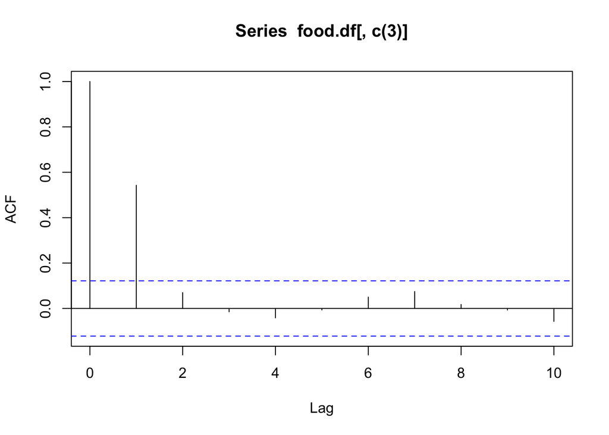

```r
foodacf = acf(food.df[,c(3)], lag.max = 10)
```

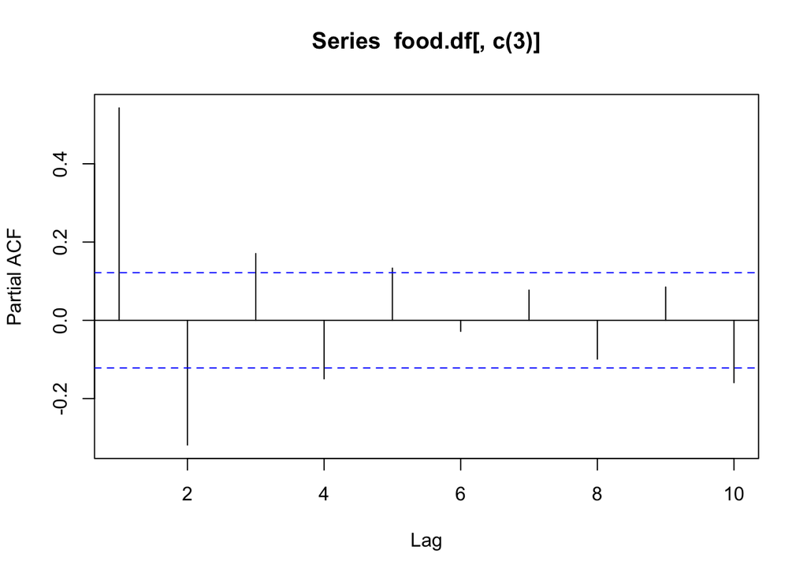

```r
foodpacf = pacf(food.df[,c(3)], lag.max = 10)
```

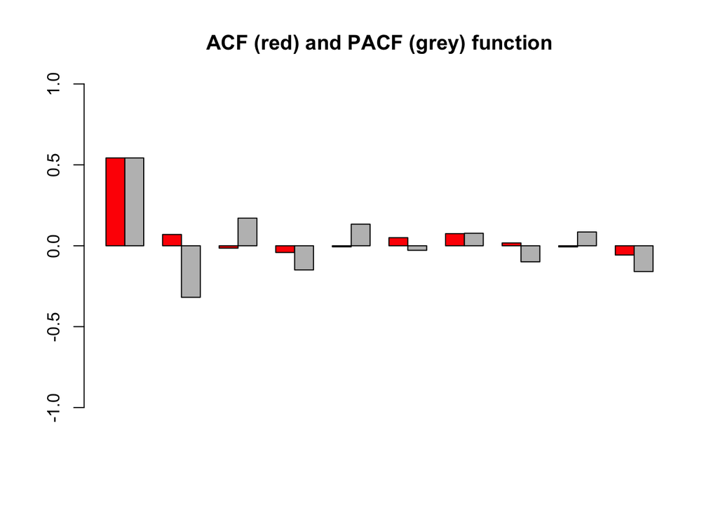

```r
barplot(bartry6, ylim = c(-1,1), main = "ACF (red) and PACF (grey) function", col = c("red", "grey"), beside = TRUE)
```

#### **auto.arima test**

```r
foodsel = food.df[,c(3)]
tsfoodsel = as.ts(foodsel)
auto.arima(tsfoodsel, test = c("adf"), trace = TRUE)
```

```
##
##  Fitting models using approximations to speed things up...
##
##  ARIMA(2,0,2) with non-zero mean : 4125.585
##  ARIMA(0,0,0) with non-zero mean : 4267.108
##  ARIMA(1,0,0) with non-zero mean : 4177.781
##  ARIMA(0,0,1) with non-zero mean : 4120.136
##  ARIMA(0,0,0) with zero mean     : 5604.798
##  ARIMA(1,0,1) with non-zero mean : 4126.435
##  ARIMA(0,0,2) with non-zero mean : 4122.028
##  ARIMA(1,0,2) with non-zero mean : 4125.076
##  ARIMA(0,0,1) with zero mean     : 5272.089
##
##  Now re-fitting the best model(s) without approximations...
##
##  ARIMA(0,0,1) with non-zero mean : 4121.316
##
##  Best model: ARIMA(0,0,1) with non-zero mean
```

```
## Series: tsfoodsel
## ARIMA(0,0,1) with non-zero mean
##
## Coefficients:
##          ma1        mean
##       0.8591  12023.7116
## s.e.  0.0340     78.4791
##
## sigma^2 estimated as 466768:  log likelihood=-2057.61
## AIC=4121.22   AICc=4121.32   BIC=4131.89
```